# HF 2 (15 pont)

- Minden feladatot a feladatszámnak megfelelő számú megoldásnotebookban oldj meg. Az első feladatot az feladat01.ipynb notebookban és így tovább.
- A megoldás tartalmazza a megoldandó feladat szövegét a megoldásnotebook első markdown cellájában!
- **Kommentekkel**, illetve **markdown cellákkal** magyarázd, hogy éppen mit csinál az adott kódrészlet!
- Magyarázat nélkül a beküldött feladatok csak fél feladatnak számítanak!
- Az elkészített ábrák minden esetben rendelkezzenek ábrafeliratokkal (cím, tengelyfeliratok és − amennyiben indokolt − jelmagyarázat)! Amennyiben a beadott ábrákon nincsenek feliratok, az adott feladat automatikusan csak fél feladatnak számít!
- A beadott notebookok Kernel -> Restart&Run All hatására a beadott formát reprodukálják! (Próbáld ki!)

## Feladat 5 (2.5 pont)

Viszgáljuk az ábrán vázolt $l$ hosszúságú matematikai ingát, amely a felfüggesztési tengelye körül el tud forogni.

[figure not shown]

A forgatását egy motor végzi, amelyik hiba nélkül konstans $\Omega$ szögsebességgel képes forgatni az ingát, azaz $\phi=\Omega t$. Az inga $l$ hossza, a $g$ gravitációs gyorsulás és az $\Omega$ szögsebesség tekinthető külső paraméternek. Az ingának egyetlen szabadsági foka van, a kitérési szög. Jelöljük ezt $\theta$-val. Ennek a fajta ingának a Lagrange-függvénye a következő alakú:

$$L=\frac{1}{2}ml^2\ddot{\theta}+\frac{1}{2}ml^2\Omega^2\sin^2{\theta}-mgl(1-\cos{\theta}).$$

A belőle képezhető differenciálegyenletrendszer pedig a következő:

$$ \frac{\mathrm{d}\theta}{\mathrm{d} t} =v_\theta\qquad (1)$$$$ \frac{\mathrm{d}v_\theta}{\mathrm{d} t} = -\frac{g}{l}\left( 1-\Omega^2\frac{g}{l}\cos{\theta} \right)\sin{\theta} \qquad (2).$$

- Oldjuk meg a fenti differenciálegyenletrendszert a következő kezdeti feltételekkel: $\theta(t=0)=0.1\mathrm{rad}$, $v_\theta(t=0)=0 \mathrm{rad/s}$ . A gravitációs gyorsulás értékét válasszuk $g=10 \mathrm{m/s}^2$-nek, az inga hosszát pedig rögzítsük $l$=1 m értékre és $\Omega$ értékét válaszd $0\mathrm{rad/s}$ és $5\mathrm{rad/s}$ között egy tetszőleges értékre. (0.5p)
- Ábrázoljuk a kapott szög és szögsebesség értékeket az első 5 másodpercben! (0.25p)
- A saját szavaiddal fogalmazd meg, hogy mekkora szögben tért ki az inga maximálisan? (0.25p)
- A kezdeti feltételeket megtartva határozzuk meg az inga maximális kitérésének $\Omega$ függését! $\Omega$ értékét a $[0,5] \mathrm{rad/s}$ intervallumot 100 pontban mintavételezve változtasd. (0.5p)
- Ábrázoljuk a maximális kitérést az $\Omega$ függvényében. (0.5p)
- A saját szavaiddal fogalmazd meg mit tapasztalunk ahogy $\Omega$ értékét egyre növeljük? Létezik olyan $\Omega$ amelynél a rendszer viselkedése megváltozik? Ha igen akkor hhatározd meg ezen $\Omega$ pontos értékét. (0.5p)

```python
%pylab inline
from scipy.integrate import *
omega=2 #a random szám amit választottam az 2
def f(u,t): # definiálom a fv-t, két változóval
    x=u[0] #majd a megoldásom első eleme lesz a kitérés
    v=u[1] # második a sebesség

    return[ v,-10*(1-omega**2*10*math.cos(x))*math.sin(x)]  #beirom a képletet, g-t és l,t számként írtam be, fejben helyettesítettem
```

```python
t=linspace(0,5,1000) # deriválok majd ezen az időtartományon
u0=[0.1,0] # kezdőértékem
u=odeint(f,u0,t) # deriválok a fv, kezdőérték, és idő tekintetében
```

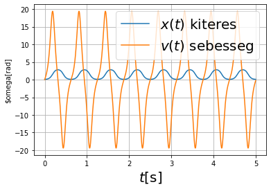

```python
plot(t,u[:,0],label=r'$x(t)$ kiteres') # plotolom kitérésként a kitérést
plot(t,u[:,1],label=r'$v(t)$ sebesseg') # sebeségként a sebességet
legend(fontsize=20)
xlabel(r'$t$[s]',fontsize=20) # elnevezem a tengelyeimet
ylabel(r'$omega[rad]')
grid()
```

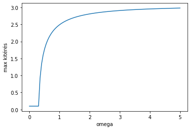

```python
maxertekek=[] #kellenek a max értékek
omegacica=linspace(0,5,100) # 0-5 között 100 értékben
for i in range (100): # végigmegyek 100 elemen
    omega=omegacica[i] #omegacica éppenediki eleme legyen az új omegám
    u=odeint(f,u0,t) # ugyanúgy deriválok, de més lett az omegám
    maxertekek.append(max(u[:,0])) # kigyüjtom táblázatba a max értékeimet


plot(omegacica,maxertekek) # itt is plotolok, és elnevezek
xlabel("omega")
ylabel('max kitérés')
```

```python
derivalas=[]
kulonbsegek=[]
for e in range(0,99): # meg akarom nézni, hogy a deriváltaknál hányadik elemaz, ahol megint nagy válltozás van
    fx=maxertekek[e] # szóval belerakom mindig a különbségeket egy táblázatba
    fd=maxertekek[e+1]-maxertekek[e] # itt elötte elneveztem a dolgokat, az egyszerúség kedvéért
    fxd=maxertekek[e+1]
    derivalas.append((fxd-fd)/fd)
for n in range (0,98):
    kulonbsegek.append(derivalas[n+1]-derivalas[n])
print(kulonbsegek)
```

[output not shown]